# 15_alternative_clustering_methods

Joanna Schroeder

9/4/2020

## Literature Review

Le Goix, R., Giraud, T., Cura, R., Le Corre, T. & Migozzi, J. (2019), "Who sells to whom in the suburbs? Home price inflation and the dynamics of sellers and buyers in the metropolitan region of Paris, 1996-2012", PLoS ONE. Vol. 14(3). e0213169.

- Ward's clustering, Chi2 distance
- No justification for selecting Ward's or for dissimilarity

Mas, J.-F., Nogueira de Vasconcelos, R. & Franca-Rocha, W. (2019), "Analysis of High Temporal Resolution Land Use/Land Cover Trajectories", Land. Vol. 8(2), pp. 30.

- Implements four different distance metrics: LCS, LSP, OM transition rates, and OM features
- Ward's method for each dissimilarity index
- Emphasizes choice for metric depends on what types of patterns of change are important: LCP focuses on beginning, OM can cluster based on rare transitions,

Kim, K. (2018), "Recent Advances in Activity-Based Travel Demand Models for Greater Flexibility". Portland State University PDXScholar. PhD Thesis, Portland, 2018. * No clustering

Riekhoff, A.-J. (2018), "Extended working lives and late-career destabilisation: A longitudinal study of Finnish register data", Advances in Life Course Research. Vol. 35, pp. 114-125. * OM and Hamming for dissimiliary * Ward's clustering

Struffolino, E. & Mortelmans, D. (2018), "Lone Mothers in Belgium: Labor Force Attachment and Risk Factors", In Bernardi, L. & Mortelmans, D. (eds) Lone Parenthood in the Life Course. Series: Life Course Research and Social Policies. Volume 8. Cham: Springer. * Hamming (higher sensitiveity to small time changes) * PAM clustering (maximizes in-group homogeneity and between-group heterogeneity)

Individual sequences were then clustered in order to maximize within-group homogeneity and between-groups heterogeneity: to this purpose, we used the partitioning around medoids method. Medoids are representative sequences having the smallest dissimilarity to the other sequences of the cluster they belong to

Studer, M., & Ritschard, G. (2016). What matters in differences between life trajectories: A comparative review of sequence dissimilarity measures. Journal of the Royal Statistical Society. A, 179(2), 481-511.

- Important aspects of sequences:
  - Timing of states (age norms, state position in life trajectory)
  - Spell duration
  - Sequencing (the order in which sequences are experienced)
- Distances between probability distributions
  - Distances between state distributions
  - Distance based on conditional distributions of sequence states (stresses the similarity of sequences that are likely to lead to the same future)
- Distances based on common attributes
  - Simple hamming distance
  - Length of longest common subsequence
  - Number of matching subsequences
- Optimal matching
  - Optimal matching principles and special cases
  - Substitution costs
    - Theory based costs
    - Costs based on state attributes
    - Data-driven costs
  - indel costs
    - Single-indel costs
    - State-dependent indel costs
  - Variants of optimal matching
    - Dynamic hamming distance
    - Localized optimal matching
    - Optimal matching sensitive to spell length
    - Optimal matching between sequences of spells
    - Optimal matching between sequences of transitions
- "Running cluster analyses with different dissimilarity measures should also allow us to de-termine whether the trajectories are primarily structured by timing, duration or sequencing differences. To achieve this, we compare cluster quality measures such as the average silhouette width of the different partitions that are obtained. In a discrepancy analysis, comparing outcomes that are obtained with different measures may also help to identify which covariates best explain sequencing differences, and which best explain timing and duration differences." (509)
  - For sequencing:
    - OMstran (low weight on state of origin), OMspell (low expansion cost e and low weight),
  - For timing:
    - Hamming family
    - "Using the CHI2- and EUCLID-distances with the number of periods K equal to the sequence length is also a solution. This K-parameter offers the advantage of allowing a smooth relaxation of exact timing alignment...CHI2 is especially interesting when we want to stress the importance of changes involving rare states." (508)
  - For duration:
    - CHI2- and EUCLID-distance with K set to 1
    - If importance of spell lengths should be stressed, OMspell with high expansion cost
    - LCS and classic OM

## Approach

Multiple dissimilarity metrics and clustering methods should be used to explore and compare outcomes. We have interested in multiple sequence dimensions (sequencing, timing, and duration), so we should implement dissimilarity metrics for coverage in each of these areas.

```r
# Import veteran job data ------
bg_vet_job <-read_csv("~/git/DSPG2020/career/data/04_bg_vet_job.csv")%>%
  mutate(year_enter_job_market = year(date_enter_job_market))%>%
  select(-noofjobs, -sector, -tenure) %>%
  group_by(id) %>%
  mutate(years_in_job_market = max(end_year) - (min(start_year)))

# What date did each veterans end their last ONET 55 job? (Date of military exit) ----
vet_endmilitary <- bg_vet_job%>%
  mutate(date_end_onet55 = if_else(is_onet55==T, enddate, as.Date(NA)))%>%
  filter(!is.na(date_end_onet55))%>%  #exluce people who don't have valid onet55 code
  select(id, date_end_onet55) %>%
  #keep the latest onet55 job
  group_by(id)%>%
  arrange(desc(date_end_onet55))%>%
  group_by(id)%>%
  distinct(id, .keep_all = TRUE)

# Join data together ------
bg_vet_job  <- inner_join(bg_vet_job, vet_endmilitary, by = "id")

# Prepare the data for sequence format ------
bg_vet_job_seq <- bg_vet_job %>%
  select(id, end_year, onet_job_zone, startdate, enddate, job_duration_day, date_end_onet55, year_enter_job_market, years_in_job_market) %>%
  mutate(year_end_onet55 = year(date_end_onet55)) %>%
  select(-year_enter_job_market) %>%
# Find jobs that came after the date ended onet55 job (Veteran career)
  filter(startdate >= date_end_onet55)%>%
# Filter out 55 jobs that have the same start and end date
  filter(onet_job_zone != 55)  %>%
  mutate(start_year = year(startdate))

# Perform check ------
#check <- bg_vet_job_seq%>%
#  mutate(year_until_first_job = start_year- year_end_onet55)%>%
#  group_by(id)%>%
#  summarize(years = min(year_until_first_job))

#ggplot(check, aes(x = years)) +
#  geom_histogram(binwidth = 1.4) +
#  labs(title = "", x = "years until first job")

#summary(check$years)

# Add variables, align sequences -----------
bg_vet_job_seq <- bg_vet_job_seq %>%
  mutate(years_after_onet55 = max(end_year) - year_end_onet55) %>%
  mutate(start_year = start_year - year_end_onet55 + 1)%>%  #transform from calender year to year start sequence analysis
  mutate(end_year = end_year - year_end_onet55 + 1) %>% #transform from calender year to year start sequence analysis
  select(id, start_year, end_year, onet_job_zone, year_end_onet55, years_after_onet55)%>%
  group_by(id)%>%
  arrange(desc(onet_job_zone))%>%
  group_by(id)%>%
  distinct(id, start_year, end_year, .keep_all = TRUE)
```

```r
# Testing using ten year veteran civilian career subset
career_sequence <- function(name = "sts_vet_ten", years) {
sts_vet <- bg_vet_job_seq %>%
  filter(years_after_onet55 >= years) %>%
  select(-years_after_onet55)

sts_vet <- as.matrix(sts_vet)
sts_vet <- as.data.frame(sts_vet)

sts_vet <- seqformat(sts_vet, from = "SPELL", to = "STS",
            id = "id",  begin = "start_year", end = "end_year",
            status = "onet_job_zone", process = FALSE)

vet.seq <- seqdef(sts_vet, left="Military transition unemployment", gaps="Civilian unemployment", right="DEL", cpal = c("#CBBEB5",  uva_color_palette[1], uva_color_palette[2],uva_color_palette[4],  uva_color_palette[6], uva_color_palette[9], "#CBBEB5", "#CBBEB5"))

# Filter out veterans who do not have a complete career in time period of interest
sts_vet <- vet.seq[, 1:years]

assign(name, sts_vet, envir = .GlobalEnv)
}

career_sequence("sts_vet_ten", 10)
```

```r
# Our OM (weighted transition)------
transition_matrix <- seqtrate(sts_vet_ten, weighted=FALSE, count=TRUE)
round(transition_matrix,2)
```

```
##                                       [-> 0] [-> 1] [-> 2] [-> 3] [-> 4] [-> 5]
## [0 ->]                                  3312      1     52     70    244     84
## [1 ->]                                     1     26      3      3      4      0
## [2 ->]                                    54      3   1874     80    128     22
## [3 ->]                                   115      1     84   2998    232     87
## [4 ->]                                   294      2     93    223   7655    185
## [5 ->]                                   106      0     38     60    204   2142
## [Military transition unemployment ->]    167      2    173    281    612    196
## [Civilian unemployment ->]                89      1     43     53    176     93
##                                       [-> Military transition unemployment]
## [0 ->]                                                                    0
## [1 ->]                                                                    0
## [2 ->]                                                                    0
## [3 ->]                                                                    0
## [4 ->]                                                                    0
## [5 ->]                                                                    0
## [Military transition unemployment ->]                                  3891
## [Civilian unemployment ->]                                                0
##                                       [-> Civilian unemployment]
## [0 ->]                                                        94
## [1 ->]                                                         0
## [2 ->]                                                        86
## [3 ->]                                                       131
## [4 ->]                                                       292
## [5 ->]                                                       121
## [Military transition unemployment ->]                          0
## [Civilian unemployment ->]                                   973
```

```r
diag(transition_matrix) = 0
round(transition_matrix,2)
```

```
##                                       [-> 0] [-> 1] [-> 2] [-> 3] [-> 4] [-> 5]
## [0 ->]                                     0      1     52     70    244     84
## [1 ->]                                     1      0      3      3      4      0
## [2 ->]                                    54      3      0     80    128     22
## [3 ->]                                   115      1     84      0    232     87
## [4 ->]                                   294      2     93    223      0    185
## [5 ->]                                   106      0     38     60    204      0
## [Military transition unemployment ->]    167      2    173    281    612    196
## [Civilian unemployment ->]                89      1     43     53    176     93
##                                       [-> Military transition unemployment]
## [0 ->]                                                                    0
## [1 ->]                                                                    0
## [2 ->]                                                                    0
## [3 ->]                                                                    0
## [4 ->]                                                                    0
## [5 ->]                                                                    0
## [Military transition unemployment ->]                                     0
## [Civilian unemployment ->]                                                0
##                                       [-> Civilian unemployment]
## [0 ->]                                                        94
## [1 ->]                                                         0
## [2 ->]                                                        86
## [3 ->]                                                       131
## [4 ->]                                                       292
## [5 ->]                                                       121
## [Military transition unemployment ->]                          0
## [Civilian unemployment ->]                                     0
```

```r
rowsum <- apply(transition_matrix, 1, sum)
for(i in 1:nrow(transition_matrix)) {
  for (j in 1:ncol(transition_matrix)){
    transition_matrix[i,j] = transition_matrix[i,j]/rowsum[i]
  }
}
for(j in 1:ncol(transition_matrix)){
      transition_matrix[8,j] = transition_matrix[8,j] = 0
}
transition_matrix <- round(transition_matrix,2)
cost_matrix <- 2-transition_matrix
round(cost_matrix,2)
```

```
##                                       [-> 0] [-> 1] [-> 2] [-> 3] [-> 4] [-> 5]
## [0 ->]                                  2.00   2.00   1.90   1.87   1.55   1.85
## [1 ->]                                  1.91   2.00   1.73   1.73   1.64   2.00
## [2 ->]                                  1.86   1.99   2.00   1.79   1.66   1.94
## [3 ->]                                  1.82   2.00   1.87   2.00   1.64   1.87
## [4 ->]                                  1.73   2.00   1.91   1.80   2.00   1.83
## [5 ->]                                  1.80   2.00   1.93   1.89   1.61   2.00
## [Military transition unemployment ->]   1.88   2.00   1.88   1.80   1.57   1.86
## [Civilian unemployment ->]              2.00   2.00   2.00   2.00   2.00   2.00
##                                       [-> Military transition unemployment]
## [0 ->]                                                                    2
## [1 ->]                                                                    2
## [2 ->]                                                                    2
## [3 ->]                                                                    2
## [4 ->]                                                                    2
## [5 ->]                                                                    2
## [Military transition unemployment ->]                                     2
## [Civilian unemployment ->]                                                2
##                                       [-> Civilian unemployment]
## [0 ->]                                                      1.83
## [1 ->]                                                      2.00
## [2 ->]                                                      1.77
## [3 ->]                                                      1.80
## [4 ->]                                                      1.73
## [5 ->]                                                      1.77
## [Military transition unemployment ->]                       2.00
## [Civilian unemployment ->]                                  2.00
```

```r
diag(cost_matrix) = 0
cost_matrix <- round(cost_matrix,2)
```

```r
# Sequencing -----------
# OM Spell, low expansion cost and low weight
weighted.spell.low <- seqdist(sts_vet_ten, method = "OMspell", indel = "auto", sm = cost_matrix, with.missing = TRUE, otto = 0, expcost = 0)

# Timing ---------------
# Hamming
hamming <- seqdist(sts_vet_ten, method = "HAM")
#CHI2 interval 10
chi2.10 <- seqdist(sts_vet_ten, method = "CHI2", step = 10)

# Duration -------------

# LCS
lcs <- seqdist(sts_vet_ten, method = "LCS")
#CHI2 interval 1
chi2.1 <- seqdist(sts_vet_ten, method = "CHI2", step = 1)
#spell, high expansion cost
weighted.spell.high <- seqdist(sts_vet_ten, method = "OMspell", indel = "auto", sm = cost_matrix, with.missing = TRUE, otto = 0.1, expcost = 1)

# Other ----------------

# Weighted OM trans
weighted <- seqdist(sts_vet_ten, method = "OMstran", indel = "auto", sm = cost_matrix, with.missing = TRUE, otto = 0.1)
# OM unweighted transition
costs.tr <- seqcost(sts_vet_ten, method = "TRATE",with.missing = FALSE)
#print(costs.tr)
unweighted <- seqdist(sts_vet_ten, method = "OMstran", indel = costs.tr$indel, sm = costs.tr$sm,with.missing = F, otto = 0.1)
# LCP
lcp <- seqdist(sts_vet_ten, method = "LCP")
```

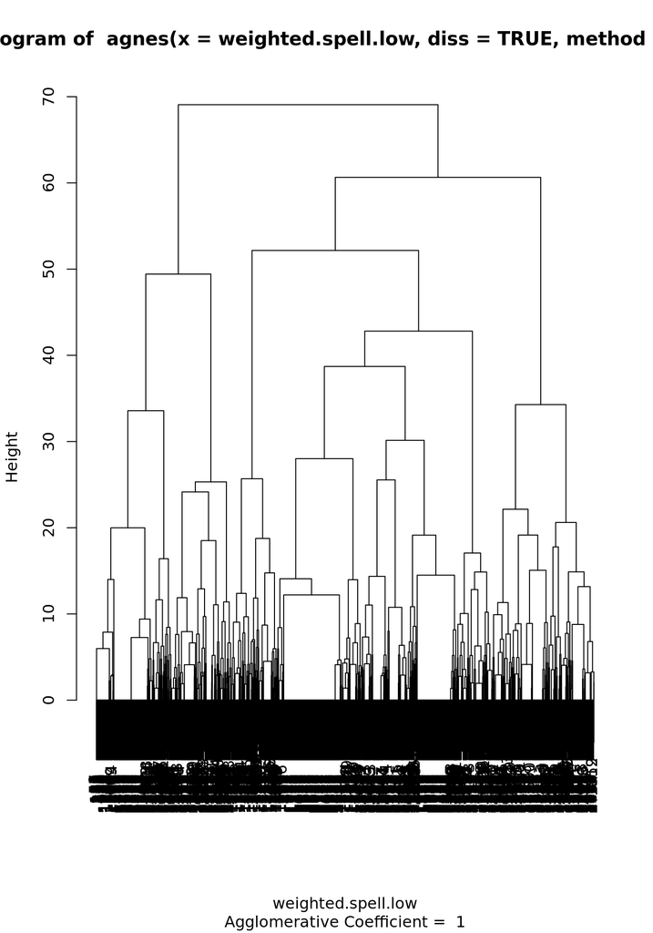

```r
# OM Spell, low expansion cost and low weight (SEQUENCING)
ward.weighted.spell.low <- agnes(weighted.spell.low, diss = TRUE, method = "ward")
plot(ward.weighted.spell.low, which.plot = 2)
```

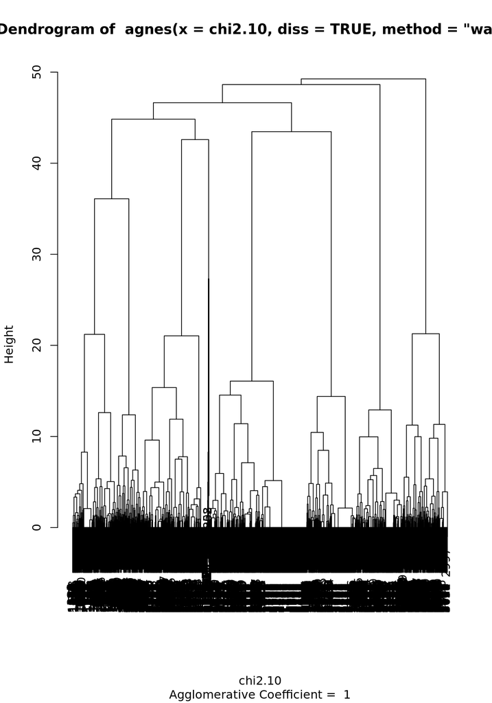

```r
ward.weighted.spell.low.8 <- cutree(ward.weighted.spell.low, k = 8)
ward.weighted.spell.low.8.fac <- factor(ward.weighted.spell.low.8, labels = paste("Type", 1:8))

#CHI2 interval 10 (TIMING)
ward.chi2.10 <- agnes(chi2.10, diss = TRUE, method = "ward")
plot(ward.chi2.10, which.plot = 2)
```

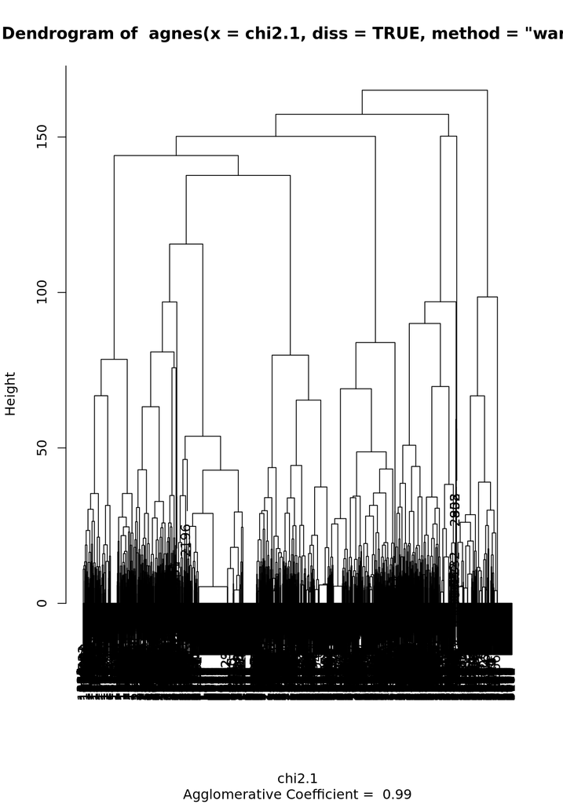

```r
ward.chi2.10.8 <- cutree(ward.chi2.10, k = 8)
ward.chi2.10.8.fac <- factor(ward.chi2.10.8, labels = paste("Type", 1:8))

#CHI2 interval 1 (DURATION)
ward.chi2.1 <- agnes(chi2.1, diss = TRUE, method = "ward")
plot(ward.chi2.1, which.plot = 2)
```

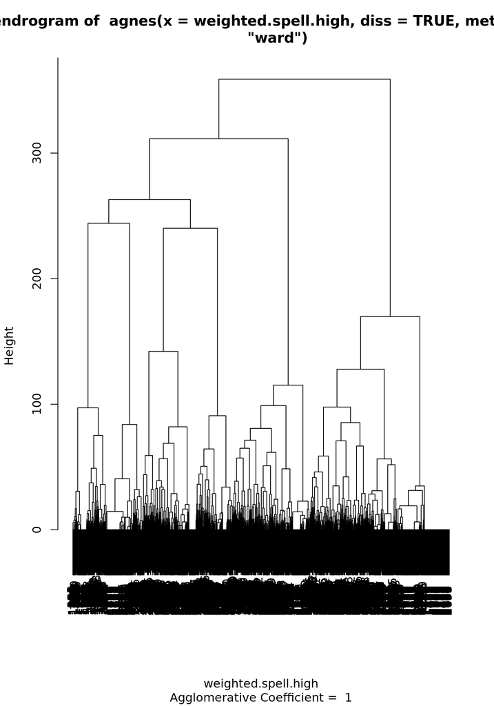

```r
ward.chi2.1.8 <- cutree(ward.chi2.1, k = 8)
ward.chi2.1.8.fac <- factor(ward.chi2.1.8, labels = paste("Type", 1:8))

#spell, high expansion cost (DURATION)
ward.weighted.spell.high <- agnes(weighted.spell.high, diss = TRUE, method = "ward")
plot(ward.weighted.spell.high, which.plot = 2)
```

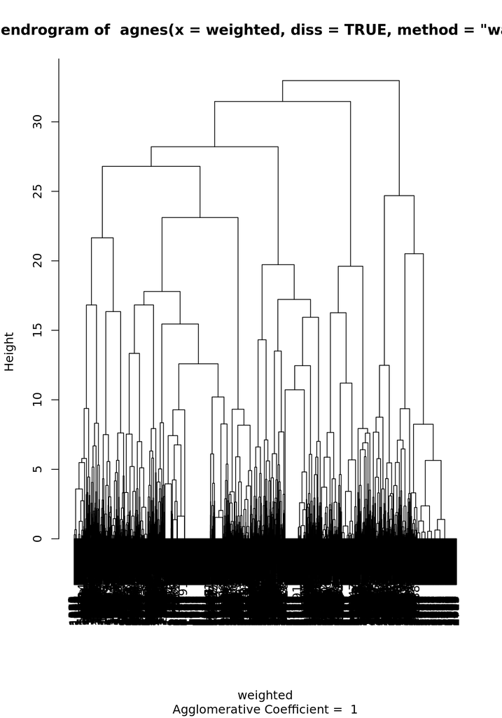

```r
ward.weighted.spell.high.8 <- cutree(ward.weighted.spell.high, k = 8)
ward.weighted.spell.high.8.fac <- factor(ward.weighted.spell.high.8, labels = paste("Type", 1:8))

# Our OM
ward.weighted <- agnes(weighted, diss = TRUE, method = "ward")
plot(ward.weighted, which.plot = 2)
```

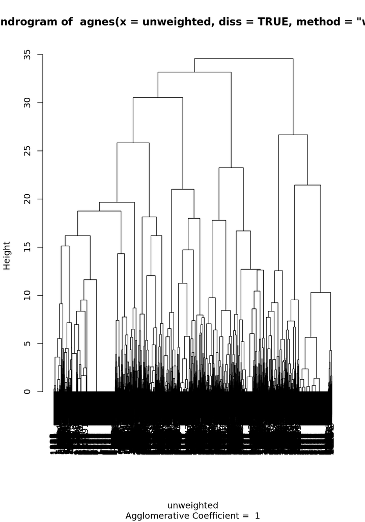

```r
ward.weighted.8 <- cutree(ward.weighted, k = 8)
ward.weighted.8.fac <- factor(ward.weighted.8, labels = paste("Type", 1:8))

# Our OM, high origin weight
#ward.weighted.otto <- agnes(weighted.otto, diss = TRUE, method = "ward")
#plot(ward.weighted.otto, which.plot = 2)
#ward.weighted.otto.8 <- cutree(ward.weighted.otto, k = 8)
#ward.weighted.otto.8.fac <- factor(ward.weighted.otto.8, labels = paste("Type", 1:8))

# OM transition
ward.unweighted <- agnes(unweighted, diss = TRUE, method = "ward")
plot(ward.unweighted, which.plot = 2)
```

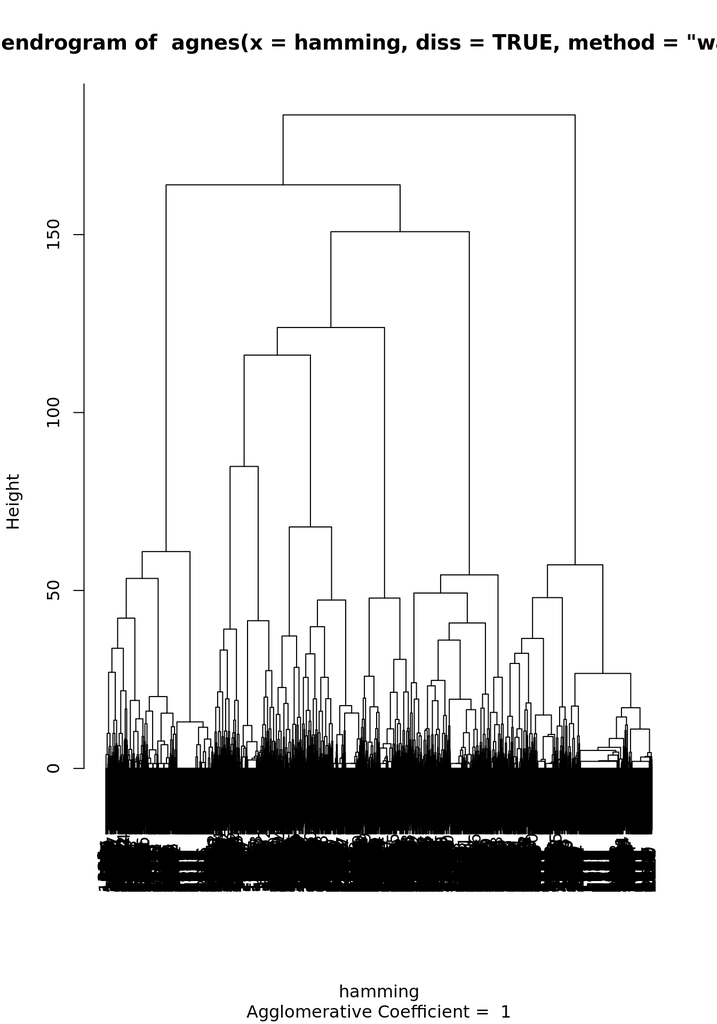

```r
ward.unweighted.8 <- cutree(ward.unweighted, k = 8)
ward.unweighted.8.fac <- factor(ward.unweighted.8, labels = paste("Type", 1:8))

# Hamming
ward.hamming <- agnes(hamming, diss = TRUE, method = "ward")
plot(ward.hamming, which.plot = 2)
```

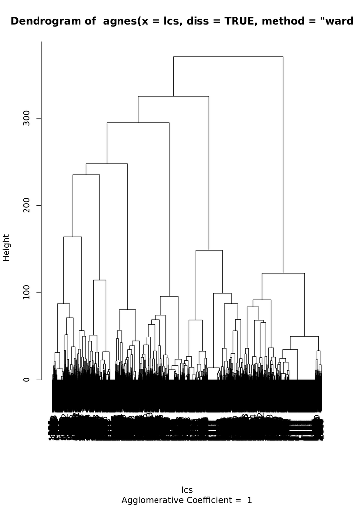

```r
ward.hamming.8 <- cutree(ward.hamming, k = 8)
ward.hamming.8.fac <- factor(ward.hamming.8, labels = paste("Type", 1:8))

# LCS
ward.lcs <- agnes(lcs, diss = TRUE, method = "ward")
plot(ward.lcs, which.plot = 2)
```

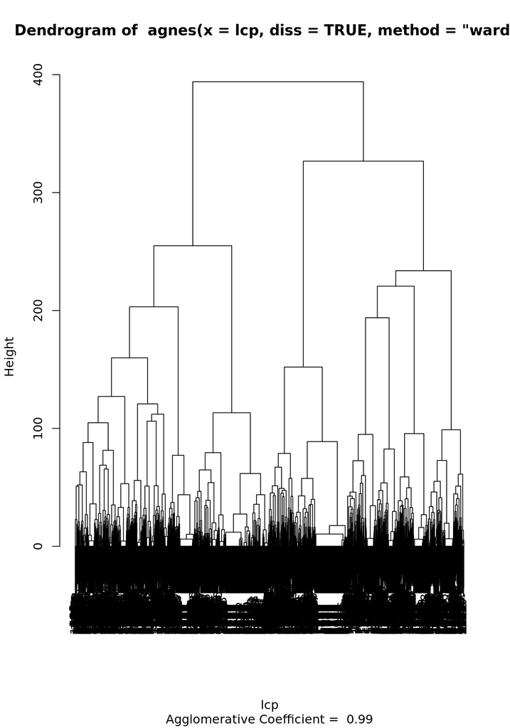

```r
ward.lcs.8 <- cutree(ward.lcs, k = 8)
ward.lcs.8.fac <- factor(ward.lcs.8, labels = paste("Type", 1:8))

# LSP
ward.lcp <- agnes(lcp, diss = TRUE, method = "ward")
plot(ward.lcp, which.plot = 2)
```

```r
ward.lcp.8 <- cutree(ward.lcp, k = 8)
ward.lcp.8.fac <- factor(ward.lcp.8, labels = paste("Type", 1:8))
```

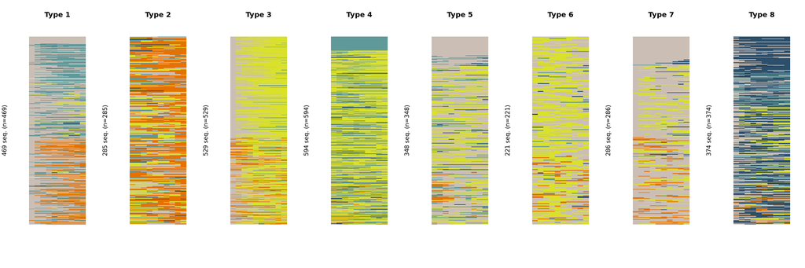

```r
# OM Spell, low expansion cost and low weight (SEQUENCING)
one <- seqIplot(sts_vet_ten, group = ward.weighted.spell.low.8.fac, cols = 8, yaxis = FALSE, axes = FALSE, with.legend = FALSE)
```

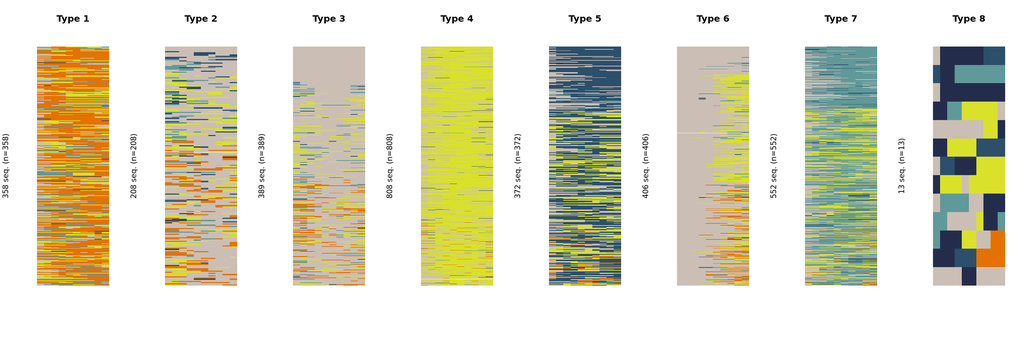

```r
#CHI2 interval 10 (TIMING)
two <- seqIplot(sts_vet_ten, group = ward.chi2.10.8.fac, cols = 8, yaxis = FALSE, axes = FALSE, with.legend = FALSE)
```

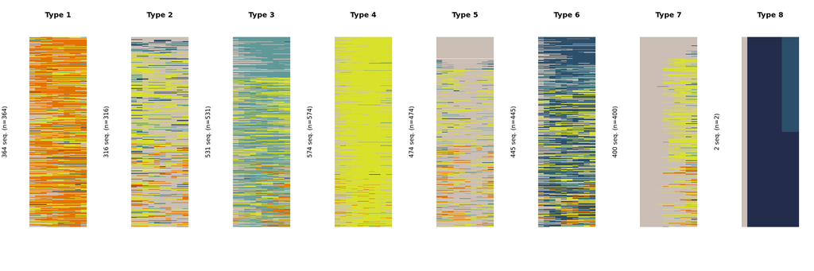

```r
#CHI2 interval 1 (DURATION)
three <- seqIplot(sts_vet_ten, group = ward.chi2.1.8.fac, cols = 8, yaxis = FALSE, axes = FALSE, with.legend = FALSE)
```

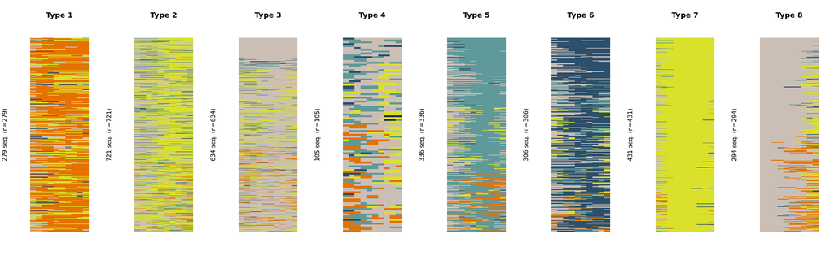

```r
#spell, high expansion cost (DURATION)
four <- seqIplot(sts_vet_ten, group = ward.weighted.spell.high.8.fac, cols = 8, yaxis = FALSE, axes = FALSE, with.legend = FALSE)
```

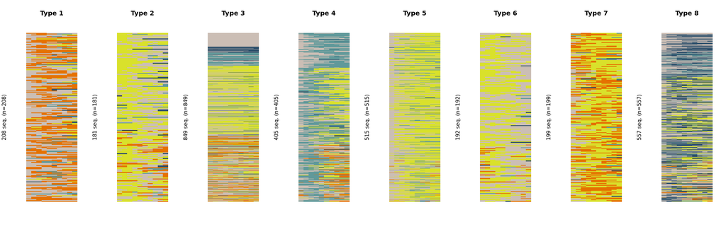

```r
#weighted
ward.weighted.plot <- seqIplot(sts_vet_ten, group = ward.weighted.8.fac, cols = 8, yaxis = FALSE, axes = FALSE, with.legend = FALSE)
```

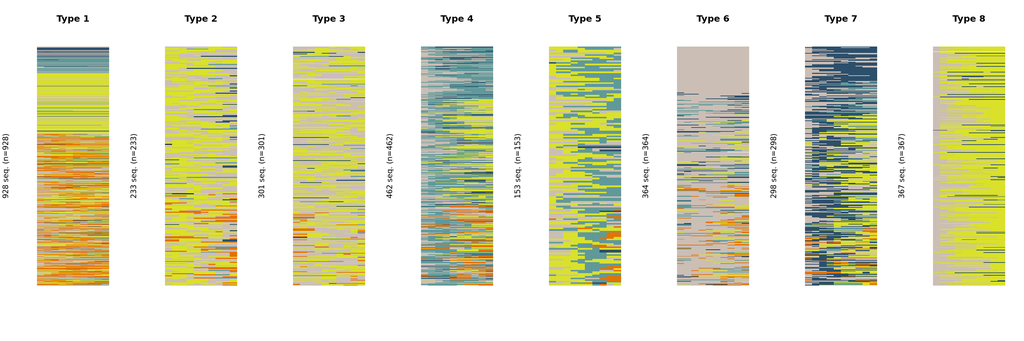

```r
#unweighted
ward.unweighted.plot <- seqIplot(sts_vet_ten, group = ward.unweighted.8.fac, cols = 8, yaxis = FALSE, axes = FALSE, with.legend = FALSE)
```

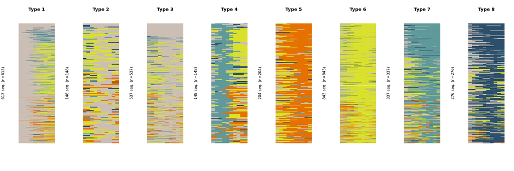

```r
#hamming
ward.hamming.plot <- seqIplot(sts_vet_ten, group = ward.hamming.8.fac, cols = 8, yaxis = FALSE, axes = FALSE, with.legend = FALSE)
```

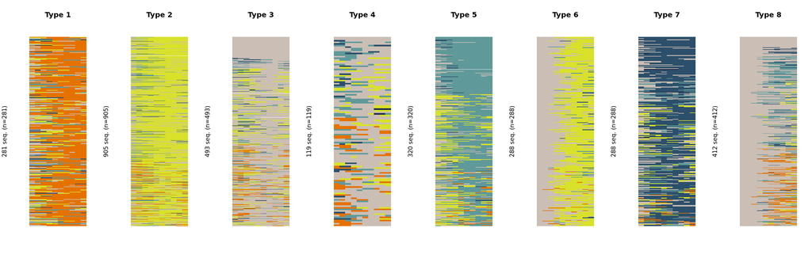

```r
#lcs
ward.lcs.plot <- seqIplot(sts_vet_ten, group = ward.lcs.8.fac, cols = 8, yaxis = FALSE, axes = FALSE, with.legend = FALSE)
```

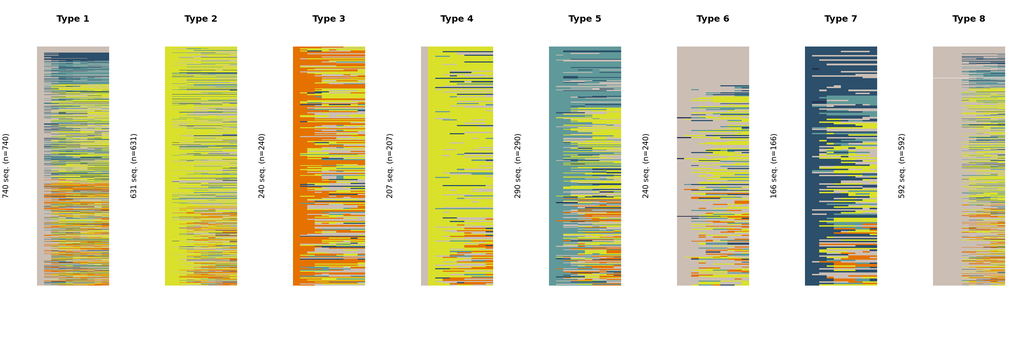

```r
#lcp
ward.lcp.plot <- seqIplot(sts_vet_ten, group = ward.lcp.8.fac, cols = 8, yaxis = FALSE, axes = FALSE, with.legend = FALSE)
```

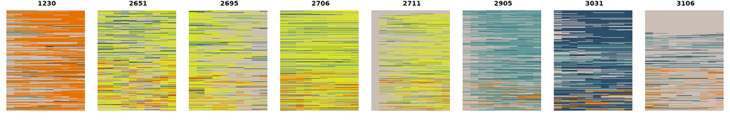

```r
library(WeightedCluster)
# OM Spell, low expansion cost and low weight
pam.weighted.spell.low <- wcKMedoids(weighted.spell.low, k = 8)
pam.weighted.spell.low.8 <- pam.weighted.spell.low$clustering

#CHI2 interval 10
pam.chi2.10 <- wcKMedoids(chi2.10, k = 8)
pam.chi2.10.8 <- pam.chi2.10$clustering

#CHI2 interval 1
pam.chi2.1 <- wcKMedoids(chi2.1, k = 8)
pam.chi2.1.8 <- pam.chi2.1$clustering

#spell, high expansion cost
pam.weighted.spell.high <- wcKMedoids(weighted.spell.high, k = 8)
pam.weighted.spell.high.8 <- pam.weighted.spell.high$clustering

# weighted --------------
pam.weighted <- wcKMedoids(weighted, k = 8)
pam.weighted.8 <- pam.weighted$clustering
# unweighted ------------
pam.unweighted <- wcKMedoids(unweighted, k = 8)
pam.unweighted.8 <- pam.unweighted$clustering
# Hamming --------------
pam.hamming <- wcKMedoids(hamming, k = 8)
pam.hamming.8 <- pam.hamming$clustering
# LCS ---------------
pam.lcs <- wcKMedoids(lcs, k = 8)
pam.lcs.8 <- pam.lcs$clustering
# LCP --------------
pam.lcp <- wcKMedoids(lcp, k = 8)
pam.lcp.8 <- pam.lcp$clustering

par(mfrow=c(1,1))
par(mar=c(1,1,1,1))

pam.weighted.spell.low.plot <- seqIplot(sts_vet_ten, group = pam.weighted.spell.low.8, cols = 8, yaxis = FALSE, axes = FALSE, with.legend = FALSE)
```

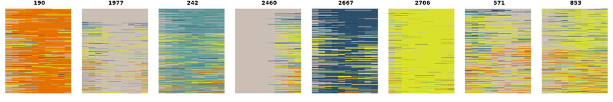

```r
pam.chi2.10.plot <- seqIplot(sts_vet_ten, group = pam.chi2.10.8, cols = 8, yaxis = FALSE, axes = FALSE, with.legend = FALSE)
```

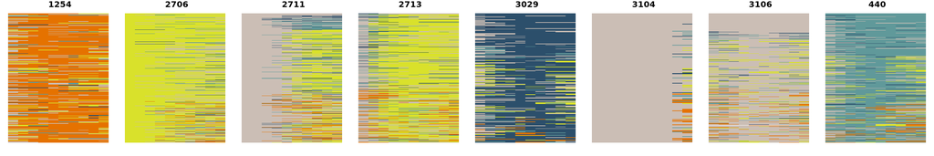

```r
pam.chi2.1.plot <- seqIplot(sts_vet_ten, group = pam.chi2.1.8, cols = 8, yaxis = FALSE, axes = FALSE, with.legend = FALSE)
```

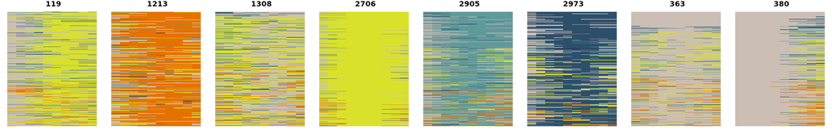

```r
pam.weighted.spell.high.plot <- seqIplot(sts_vet_ten, group = pam.weighted.spell.high.8, cols = 8, yaxis = FALSE, axes = FALSE, with.legend = FALSE)
```

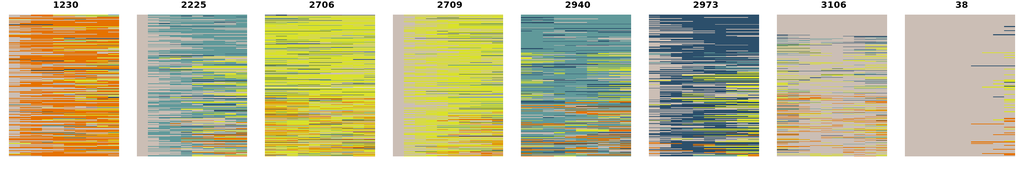

```r
#weighted
pam.weighted.plot <- seqIplot(sts_vet_ten, group = pam.weighted.8, cols = 8, yaxis = FALSE, axes = FALSE, with.legend = FALSE)
```

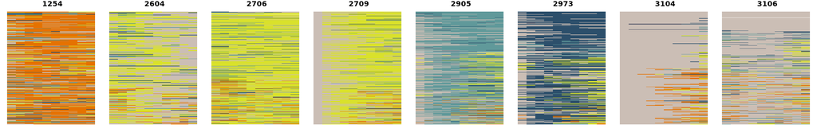

```r
#unweighted
pam.unweighted.plot <- seqIplot(sts_vet_ten, group = pam.unweighted.8, cols = 8, yaxis = FALSE, axes = FALSE, with.legend = FALSE)
```

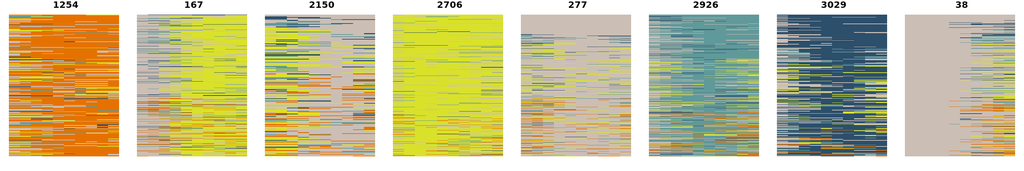

```r
#hamming
pam.hamming.plot <- seqIplot(sts_vet_ten, group = pam.hamming.8, cols = 8, yaxis = FALSE, axes = FALSE, with.legend = FALSE)
```

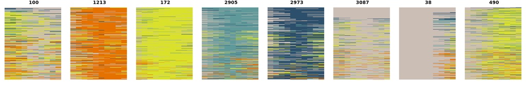

```r
#lcs
pam.lcs.plot <- seqIplot(sts_vet_ten, group = pam.lcs.8, cols = 8, yaxis = FALSE, axes = FALSE, with.legend = FALSE)
```

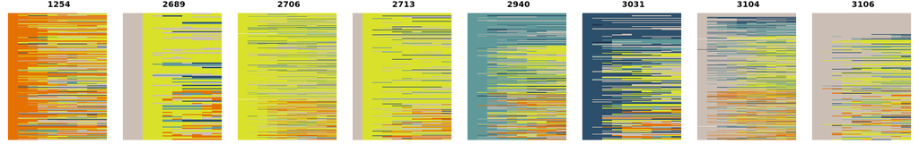

```r
#lcp
pam.lcp.plot <- seqIplot(sts_vet_ten, group = pam.lcp.8, cols = 8, yaxis = FALSE, axes = FALSE, with.legend = FALSE)
```

```r
hamming.labels <- c("Zone 5", "Unemployment to Zone 4", "Missing zone", "Zone 4", "Civilian unemployment", "Zone 2", "Zone 3", "Transitional unemployment")
pam.hamming.8.factor <- factor(pam.hamming.8, levels = c(1254, 167, 2150, 2706, 277, 2926, 3029, 38), labels = hamming.labels)
```

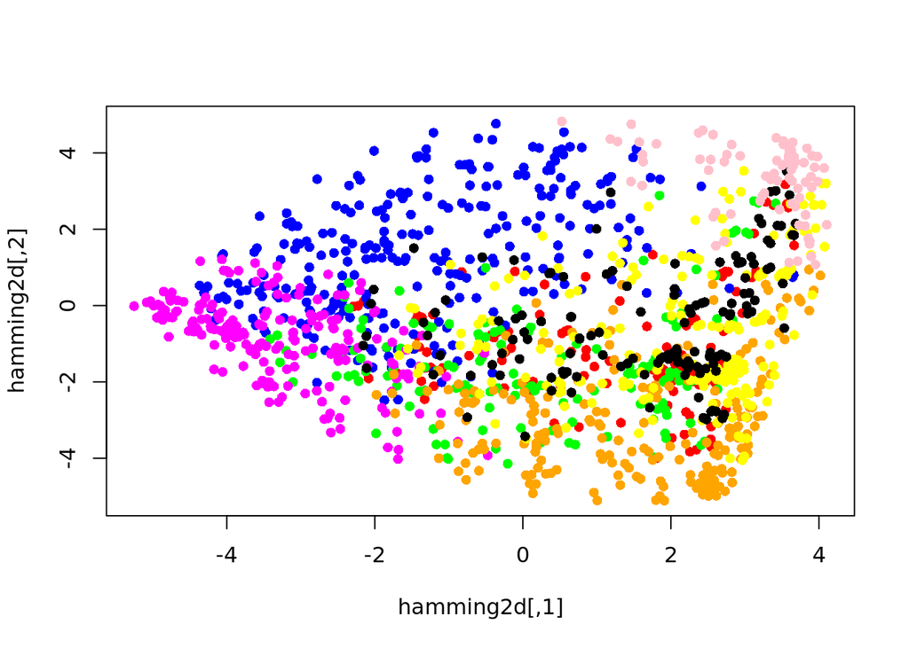

```r
plot.new()
hamming2d <- cmdscale(hamming, k = 2)
plot(hamming2d, type = "n")
points(hamming2d[pam.hamming.8.factor == "Zone 5", ], pch = 16, col = "red")
points(hamming2d[pam.hamming.8.factor == "Unemployment to Zone 4", ], pch = 16, col = "blue")
points(hamming2d[pam.hamming.8.factor == "Missing zone", ], pch = 16, col = "green")
points(hamming2d[pam.hamming.8.factor == "Zone 4", ], pch = 16, col = "magenta")
points(hamming2d[pam.hamming.8.factor == "Civilian unemployment", ], pch = 16, col = "orange")
points(hamming2d[pam.hamming.8.factor == "Zone 2", ], pch = 16, col = "yellow")
points(hamming2d[pam.hamming.8.factor == "Zone 3", ], pch = 16, col = "black")
points(hamming2d[pam.hamming.8.factor == "Transitional unemployment", ], pch = 16, col = "pink")
```

```r
#legend("bottomright", fill = c("red", "blue", "green", "magenta", "orange", "yellow", "black", "pink"), legend = pam.hamming.8.factor)
```